# Risk Factor Analysis

## Outcome Variable

**Outcome Variable:** ever_wasted

## Predictor Variables

**Intervention Variable:** exclfeed36

**Adjustment Set:**

unadjusted

## Stratifying Variables

The analysis was stratified on these variable(s):

- agecat
- studyid
- country

## Data Summary

| agecat | studyid | country | exclfeed36 | ever_wasted | n_cell | n |
| --- | --- | --- | --- | --- | --- | --- |
| 0-24 months (no birth wast) | CMC-V-BCS-2002 | INDIA | 1 | 0 | 7 | 9 |
| 0-24 months (no birth wast) | CMC-V-BCS-2002 | INDIA | 1 | 1 | 2 | 9 |
| 0-24 months (no birth wast) | CMC-V-BCS-2002 | INDIA | 0 | 0 | 0 | 9 |
| 0-24 months (no birth wast) | CMC-V-BCS-2002 | INDIA | 0 | 1 | 0 | 9 |
| 0-24 months (no birth wast) | EE | PAKISTAN | 1 | 0 | 3 | 9 |
| 0-24 months (no birth wast) | EE | PAKISTAN | 1 | 1 | 1 | 9 |
| 0-24 months (no birth wast) | EE | PAKISTAN | 0 | 0 | 3 | 9 |
| 0-24 months (no birth wast) | EE | PAKISTAN | 0 | 1 | 2 | 9 |
| 0-24 months (no birth wast) | GMS-Nepal | NEPAL | 1 | 0 | 180 | 524 |
| 0-24 months (no birth wast) | GMS-Nepal | NEPAL | 1 | 1 | 240 | 524 |
| 0-24 months (no birth wast) | GMS-Nepal | NEPAL | 0 | 0 | 47 | 524 |
| 0-24 months (no birth wast) | GMS-Nepal | NEPAL | 0 | 1 | 57 | 524 |
| 0-24 months (no birth wast) | IRC | INDIA | 1 | 0 | 0 | 4 |
| 0-24 months (no birth wast) | IRC | INDIA | 1 | 1 | 0 | 4 |
| 0-24 months (no birth wast) | IRC | INDIA | 0 | 0 | 1 | 4 |
| 0-24 months (no birth wast) | IRC | INDIA | 0 | 1 | 3 | 4 |
| 0-24 months (no birth wast) | Keneba | GAMBIA | 1 | 0 | 405 | 1974 |
| 0-24 months (no birth wast) | Keneba | GAMBIA | 1 | 1 | 218 | 1974 |
| 0-24 months (no birth wast) | Keneba | GAMBIA | 0 | 0 | 789 | 1974 |
| 0-24 months (no birth wast) | Keneba | GAMBIA | 0 | 1 | 562 | 1974 |
| 0-24 months (no birth wast) | LCNI-5 | MALAWI | 1 | 0 | 42 | 271 |
| 0-24 months (no birth wast) | LCNI-5 | MALAWI | 1 | 1 | 5 | 271 |
| 0-24 months (no birth wast) | LCNI-5 | MALAWI | 0 | 0 | 204 | 271 |
| 0-24 months (no birth wast) | LCNI-5 | MALAWI | 0 | 1 | 20 | 271 |
| 0-24 months (no birth wast) | MAL-ED | BANGLADESH | 1 | 0 | 27 | 251 |
| 0-24 months (no birth wast) | MAL-ED | BANGLADESH | 1 | 1 | 6 | 251 |
| 0-24 months (no birth wast) | MAL-ED | BANGLADESH | 0 | 0 | 167 | 251 |
| 0-24 months (no birth wast) | MAL-ED | BANGLADESH | 0 | 1 | 51 | 251 |
| 0-24 months (no birth wast) | MAL-ED | BRAZIL | 1 | 0 | 16 | 224 |
| 0-24 months (no birth wast) | MAL-ED | BRAZIL | 1 | 1 | 0 | 224 |

[output cut: 150 more lines]

The following strata were considered:

- agecat: 0-24 months (no birth wast), studyid: CMC-V-BCS-2002, country: INDIA
- agecat: 0-24 months (no birth wast), studyid: EE, country: PAKISTAN
- agecat: 0-24 months (no birth wast), studyid: GMS-Nepal, country: NEPAL
- agecat: 0-24 months (no birth wast), studyid: IRC, country: INDIA
- agecat: 0-24 months (no birth wast), studyid: Keneba, country: GAMBIA
- agecat: 0-24 months (no birth wast), studyid: LCNI-5, country: MALAWI
- agecat: 0-24 months (no birth wast), studyid: MAL-ED, country: BANGLADESH
- agecat: 0-24 months (no birth wast), studyid: MAL-ED, country: BRAZIL
- agecat: 0-24 months (no birth wast), studyid: MAL-ED, country: INDIA
- agecat: 0-24 months (no birth wast), studyid: MAL-ED, country: NEPAL
- agecat: 0-24 months (no birth wast), studyid: MAL-ED, country: PERU
- agecat: 0-24 months (no birth wast), studyid: MAL-ED, country: SOUTH AFRICA
- agecat: 0-24 months (no birth wast), studyid: MAL-ED, country: TANZANIA, UNITED REPUBLIC OF
- agecat: 0-24 months (no birth wast), studyid: PROVIDE, country: BANGLADESH
- agecat: 0-24 months (no birth wast), studyid: SAS-FoodSuppl, country: INDIA
- agecat: 0-6 months (no birth wast), studyid: CMC-V-BCS-2002, country: INDIA
- agecat: 0-6 months (no birth wast), studyid: EE, country: PAKISTAN
- agecat: 0-6 months (no birth wast), studyid: GMS-Nepal, country: NEPAL
- agecat: 0-6 months (no birth wast), studyid: IRC, country: INDIA
- agecat: 0-6 months (no birth wast), studyid: Keneba, country: GAMBIA
- agecat: 0-6 months (no birth wast), studyid: LCNI-5, country: MALAWI
- agecat: 0-6 months (no birth wast), studyid: MAL-ED, country: BANGLADESH
- agecat: 0-6 months (no birth wast), studyid: MAL-ED, country: BRAZIL
- agecat: 0-6 months (no birth wast), studyid: MAL-ED, country: INDIA
- agecat: 0-6 months (no birth wast), studyid: MAL-ED, country: NEPAL
- agecat: 0-6 months (no birth wast), studyid: MAL-ED, country: PERU
- agecat: 0-6 months (no birth wast), studyid: MAL-ED, country: SOUTH AFRICA
- agecat: 0-6 months (no birth wast), studyid: MAL-ED, country: TANZANIA, UNITED REPUBLIC OF
- agecat: 0-6 months (no birth wast), studyid: PROVIDE, country: BANGLADESH
- agecat: 0-6 months (no birth wast), studyid: SAS-FoodSuppl, country: INDIA
- agecat: 6-24 months, studyid: CMC-V-BCS-2002, country: INDIA
- agecat: 6-24 months, studyid: EE, country: PAKISTAN
- agecat: 6-24 months, studyid: GMS-Nepal, country: NEPAL
- agecat: 6-24 months, studyid: IRC, country: INDIA
- agecat: 6-24 months, studyid: Keneba, country: GAMBIA
- agecat: 6-24 months, studyid: LCNI-5, country: MALAWI
- agecat: 6-24 months, studyid: MAL-ED, country: BANGLADESH
- agecat: 6-24 months, studyid: MAL-ED, country: BRAZIL
- agecat: 6-24 months, studyid: MAL-ED, country: INDIA
- agecat: 6-24 months, studyid: MAL-ED, country: NEPAL
- agecat: 6-24 months, studyid: MAL-ED, country: PERU
- agecat: 6-24 months, studyid: MAL-ED, country: SOUTH AFRICA
- agecat: 6-24 months, studyid: MAL-ED, country: TANZANIA, UNITED REPUBLIC OF
- agecat: 6-24 months, studyid: PROVIDE, country: BANGLADESH
- agecat: 6-24 months, studyid: SAS-FoodSuppl, country: INDIA

### Dropped Strata

Some strata were dropped due to rare outcomes:

- agecat: 0-24 months (no birth wast), studyid: CMC-V-BCS-2002, country: INDIA
- agecat: 0-24 months (no birth wast), studyid: EE, country: PAKISTAN
- agecat: 0-24 months (no birth wast), studyid: IRC, country: INDIA
- agecat: 0-24 months (no birth wast), studyid: MAL-ED, country: BRAZIL
- agecat: 0-24 months (no birth wast), studyid: MAL-ED, country: NEPAL
- agecat: 0-24 months (no birth wast), studyid: MAL-ED, country: PERU
- agecat: 0-24 months (no birth wast), studyid: MAL-ED, country: SOUTH AFRICA
- agecat: 0-24 months (no birth wast), studyid: MAL-ED, country: TANZANIA, UNITED REPUBLIC OF
- agecat: 0-24 months (no birth wast), studyid: SAS-FoodSuppl, country: INDIA
- agecat: 0-6 months (no birth wast), studyid: CMC-V-BCS-2002, country: INDIA
- agecat: 0-6 months (no birth wast), studyid: EE, country: PAKISTAN
- agecat: 0-6 months (no birth wast), studyid: IRC, country: INDIA
- agecat: 0-6 months (no birth wast), studyid: LCNI-5, country: MALAWI
- agecat: 0-6 months (no birth wast), studyid: MAL-ED, country: BANGLADESH
- agecat: 0-6 months (no birth wast), studyid: MAL-ED, country: BRAZIL
- agecat: 0-6 months (no birth wast), studyid: MAL-ED, country: INDIA
- agecat: 0-6 months (no birth wast), studyid: MAL-ED, country: NEPAL
- agecat: 0-6 months (no birth wast), studyid: MAL-ED, country: PERU
- agecat: 0-6 months (no birth wast), studyid: MAL-ED, country: SOUTH AFRICA
- agecat: 0-6 months (no birth wast), studyid: MAL-ED, country: TANZANIA, UNITED REPUBLIC OF
- agecat: 0-6 months (no birth wast), studyid: SAS-FoodSuppl, country: INDIA
- agecat: 6-24 months, studyid: CMC-V-BCS-2002, country: INDIA
- agecat: 6-24 months, studyid: EE, country: PAKISTAN
- agecat: 6-24 months, studyid: IRC, country: INDIA
- agecat: 6-24 months, studyid: MAL-ED, country: BRAZIL
- agecat: 6-24 months, studyid: MAL-ED, country: INDIA
- agecat: 6-24 months, studyid: MAL-ED, country: NEPAL
- agecat: 6-24 months, studyid: MAL-ED, country: PERU
- agecat: 6-24 months, studyid: MAL-ED, country: SOUTH AFRICA
- agecat: 6-24 months, studyid: MAL-ED, country: TANZANIA, UNITED REPUBLIC OF
- agecat: 6-24 months, studyid: SAS-FoodSuppl, country: INDIA

## Methods Detail

We’re interested in the causal parameters $E[Y_a]$ for all values of $a \in \mathcal{A}$. These parameters represent the mean outcome if, possibly contrary to fact, we intervened to set all units to have $A=a$. Under the randomization and positivity assumptions, these are identified by the statistical parameters $\psi_a=E_W[E_{Y|A,W}(Y|A=a,W)]$. In addition, we’re interested in the mean of $Y$, $E[Y]$ under no intervention (the observed mean). We will estimate these parameters by using SuperLearner to fit the relevant likelihood factors – $E_{Y|A,W}(Y|A=a,W)$ and $p(A=a|W)$, and then updating our likelihood fit using a joint TMLE.

For unadjusted analyses ($W=\{\}$), initial likelihoods were estimated using Lrnr_glm to estimate the simple $E(Y|A)$ and Lrnr_mean to estimate $p(A)$. For adjusted analyses, a small library containing Lrnr_glmnet, Lrnr_xgboost, and Lrnr_mean was used.

Having estimated these parameters, we will then use the delta method to estimate relative risks and attributable risks relative to a prespecified baseline level of $A$.

# Results Detail

## Results Plots

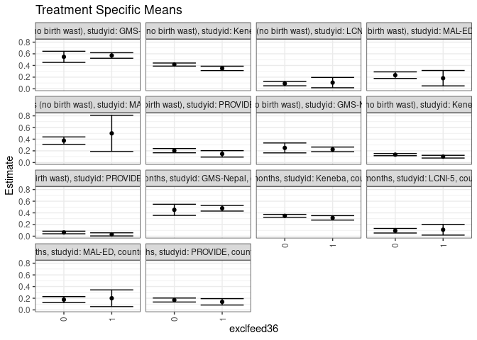

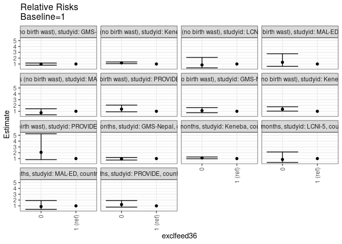

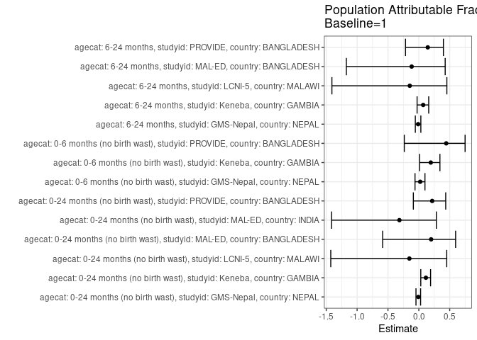

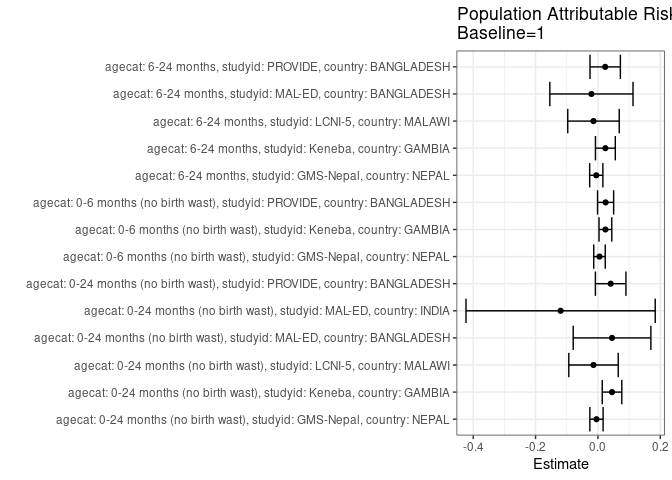

## Results Table

### Parameter: TSM

| agecat | studyid | country | intervention_level | baseline_level | estimate | ci_lower | ci_upper |
| --- | --- | --- | --- | --- | --- | --- | --- |
| 0-24 months (no birth wast) | GMS-Nepal | NEPAL | 1 | NA | 0.5714286 | 0.5240556 | 0.6188016 |
| 0-24 months (no birth wast) | GMS-Nepal | NEPAL | 0 | NA | 0.5480769 | 0.4523356 | 0.6438182 |
| 0-24 months (no birth wast) | Keneba | GAMBIA | 1 | NA | 0.3499197 | 0.3124585 | 0.3873810 |
| 0-24 months (no birth wast) | Keneba | GAMBIA | 0 | NA | 0.4159882 | 0.3896987 | 0.4422776 |
| 0-24 months (no birth wast) | LCNI-5 | MALAWI | 1 | NA | 0.1063830 | 0.0180722 | 0.1946938 |
| 0-24 months (no birth wast) | LCNI-5 | MALAWI | 0 | NA | 0.0892857 | 0.0518739 | 0.1266975 |
| 0-24 months (no birth wast) | MAL-ED | BANGLADESH | 1 | NA | 0.1818182 | 0.0499617 | 0.3136747 |
| 0-24 months (no birth wast) | MAL-ED | BANGLADESH | 0 | NA | 0.2339450 | 0.1776365 | 0.2902534 |
| 0-24 months (no birth wast) | MAL-ED | INDIA | 1 | NA | 0.5000000 | 0.1894382 | 0.8105618 |
| 0-24 months (no birth wast) | MAL-ED | INDIA | 0 | NA | 0.3750000 | 0.3114655 | 0.4385345 |
| 0-24 months (no birth wast) | PROVIDE | BANGLADESH | 1 | NA | 0.1481481 | 0.0934008 | 0.2028955 |
| 0-24 months (no birth wast) | PROVIDE | BANGLADESH | 0 | NA | 0.2029598 | 0.1666850 | 0.2392346 |
| 0-6 months (no birth wast) | GMS-Nepal | NEPAL | 1 | NA | 0.2243902 | 0.1839693 | 0.2648111 |
| 0-6 months (no birth wast) | GMS-Nepal | NEPAL | 0 | NA | 0.2500000 | 0.1650477 | 0.3349523 |
| 0-6 months (no birth wast) | Keneba | GAMBIA | 1 | NA | 0.1000000 | 0.0763798 | 0.1236202 |
| 0-6 months (no birth wast) | Keneba | GAMBIA | 0 | NA | 0.1350746 | 0.1167691 | 0.1533802 |
| 0-6 months (no birth wast) | PROVIDE | BANGLADESH | 1 | NA | 0.0308642 | 0.0042107 | 0.0575177 |
| 0-6 months (no birth wast) | PROVIDE | BANGLADESH | 0 | NA | 0.0639659 | 0.0418030 | 0.0861288 |
| 6-24 months | GMS-Nepal | NEPAL | 1 | NA | 0.4786730 | 0.4309663 | 0.5263797 |
| 6-24 months | GMS-Nepal | NEPAL | 0 | NA | 0.4519231 | 0.3561821 | 0.5476640 |
| 6-24 months | Keneba | GAMBIA | 1 | NA | 0.3143351 | 0.2765104 | 0.3521597 |
| 6-24 months | Keneba | GAMBIA | 0 | NA | 0.3486792 | 0.3230129 | 0.3743456 |
| 6-24 months | LCNI-5 | MALAWI | 1 | NA | 0.1111111 | 0.0191112 | 0.2031111 |
| 6-24 months | LCNI-5 | MALAWI | 0 | NA | 0.0938967 | 0.0546489 | 0.1331445 |
| 6-24 months | MAL-ED | BANGLADESH | 1 | NA | 0.2000000 | 0.0565653 | 0.3434347 |
| 6-24 months | MAL-ED | BANGLADESH | 0 | NA | 0.1761905 | 0.1245548 | 0.2278261 |
| 6-24 months | PROVIDE | BANGLADESH | 1 | NA | 0.1381579 | 0.0832566 | 0.1930592 |
| 6-24 months | PROVIDE | BANGLADESH | 0 | NA | 0.1691974 | 0.1349445 | 0.2034503 |

### Parameter: E(Y)

| agecat | studyid | country | intervention_level | baseline_level | estimate | ci_lower | ci_upper |
| --- | --- | --- | --- | --- | --- | --- | --- |
| 0-24 months (no birth wast) | GMS-Nepal | NEPAL | NA | NA | 0.5667939 | 0.5243264 | 0.6092614 |
| 0-24 months (no birth wast) | Keneba | GAMBIA | NA | NA | 0.3951368 | 0.3735650 | 0.4167086 |
| 0-24 months (no birth wast) | LCNI-5 | MALAWI | NA | NA | 0.0922509 | 0.0577338 | 0.1267680 |
| 0-24 months (no birth wast) | MAL-ED | BANGLADESH | NA | NA | 0.2270916 | 0.1751587 | 0.2790245 |
| 0-24 months (no birth wast) | MAL-ED | INDIA | NA | NA | 0.3803419 | 0.3180067 | 0.4426771 |
| 0-24 months (no birth wast) | PROVIDE | BANGLADESH | NA | NA | 0.1889764 | 0.1585028 | 0.2194500 |
| 0-6 months (no birth wast) | GMS-Nepal | NEPAL | NA | NA | 0.2294118 | 0.1928853 | 0.2659383 |
| 0-6 months (no birth wast) | Keneba | GAMBIA | NA | NA | 0.1239796 | 0.1093860 | 0.1385732 |
| 0-6 months (no birth wast) | PROVIDE | BANGLADESH | NA | NA | 0.0554675 | 0.0375942 | 0.0733408 |
| 6-24 months | GMS-Nepal | NEPAL | NA | NA | 0.4733840 | 0.4306748 | 0.5160933 |
| 6-24 months | Keneba | GAMBIA | NA | NA | 0.3382353 | 0.3169789 | 0.3594917 |
| 6-24 months | LCNI-5 | MALAWI | NA | NA | 0.0968992 | 0.0607324 | 0.1330660 |
| 6-24 months | MAL-ED | BANGLADESH | NA | NA | 0.1791667 | 0.1305478 | 0.2277856 |
| 6-24 months | PROVIDE | BANGLADESH | NA | NA | 0.1615008 | 0.1323459 | 0.1906557 |

### Parameter: RR

| agecat | studyid | country | intervention_level | baseline_level | estimate | ci_lower | ci_upper |
| --- | --- | --- | --- | --- | --- | --- | --- |
| 0-24 months (no birth wast) | GMS-Nepal | NEPAL | 1 | 1 | 1.0000000 | 1.0000000 | 1.000000 |
| 0-24 months (no birth wast) | GMS-Nepal | NEPAL | 0 | 1 | 0.9591346 | 0.7905047 | 1.163736 |
| 0-24 months (no birth wast) | Keneba | GAMBIA | 1 | 1 | 1.0000000 | 1.0000000 | 1.000000 |
| 0-24 months (no birth wast) | Keneba | GAMBIA | 0 | 1 | 1.1888102 | 1.0498367 | 1.346181 |
| 0-24 months (no birth wast) | LCNI-5 | MALAWI | 1 | 1 | 1.0000000 | 1.0000000 | 1.000000 |
| 0-24 months (no birth wast) | LCNI-5 | MALAWI | 0 | 1 | 0.8392857 | 0.3311837 | 2.126918 |
| 0-24 months (no birth wast) | MAL-ED | BANGLADESH | 1 | 1 | 1.0000000 | 1.0000000 | 1.000000 |
| 0-24 months (no birth wast) | MAL-ED | BANGLADESH | 0 | 1 | 1.2866972 | 0.5992775 | 2.762643 |
| 0-24 months (no birth wast) | MAL-ED | INDIA | 1 | 1 | 1.0000000 | 1.0000000 | 1.000000 |
| 0-24 months (no birth wast) | MAL-ED | INDIA | 0 | 1 | 0.7500000 | 0.3939629 | 1.427799 |
| 0-24 months (no birth wast) | PROVIDE | BANGLADESH | 1 | 1 | 1.0000000 | 1.0000000 | 1.000000 |
| 0-24 months (no birth wast) | PROVIDE | BANGLADESH | 0 | 1 | 1.3699789 | 0.9087358 | 2.065333 |
| 0-6 months (no birth wast) | GMS-Nepal | NEPAL | 1 | 1 | 1.0000000 | 1.0000000 | 1.000000 |
| 0-6 months (no birth wast) | GMS-Nepal | NEPAL | 0 | 1 | 1.1141304 | 0.7584119 | 1.636692 |
| 0-6 months (no birth wast) | Keneba | GAMBIA | 1 | 1 | 1.0000000 | 1.0000000 | 1.000000 |
| 0-6 months (no birth wast) | Keneba | GAMBIA | 0 | 1 | 1.3507463 | 1.0287434 | 1.773538 |
| 0-6 months (no birth wast) | PROVIDE | BANGLADESH | 1 | 1 | 1.0000000 | 1.0000000 | 1.000000 |
| 0-6 months (no birth wast) | PROVIDE | BANGLADESH | 0 | 1 | 2.0724947 | 0.8173110 | 5.255324 |
| 6-24 months | GMS-Nepal | NEPAL | 1 | 1 | 1.0000000 | 1.0000000 | 1.000000 |
| 6-24 months | GMS-Nepal | NEPAL | 0 | 1 | 0.9441165 | 0.7470445 | 1.193177 |
| 6-24 months | Keneba | GAMBIA | 1 | 1 | 1.0000000 | 1.0000000 | 1.000000 |
| 6-24 months | Keneba | GAMBIA | 0 | 1 | 1.1092598 | 0.9633210 | 1.277308 |
| 6-24 months | LCNI-5 | MALAWI | 1 | 1 | 1.0000000 | 1.0000000 | 1.000000 |
| 6-24 months | LCNI-5 | MALAWI | 0 | 1 | 0.8450704 | 0.3342527 | 2.136539 |
| 6-24 months | MAL-ED | BANGLADESH | 1 | 1 | 1.0000000 | 1.0000000 | 1.000000 |
| 6-24 months | MAL-ED | BANGLADESH | 0 | 1 | 0.8809524 | 0.4059626 | 1.911696 |
| 6-24 months | PROVIDE | BANGLADESH | 1 | 1 | 1.0000000 | 1.0000000 | 1.000000 |
| 6-24 months | PROVIDE | BANGLADESH | 0 | 1 | 1.2246669 | 0.7840304 | 1.912947 |

### Parameter: PAR

| agecat | studyid | country | intervention_level | baseline_level | estimate | ci_lower | ci_upper |
| --- | --- | --- | --- | --- | --- | --- | --- |
| 0-24 months (no birth wast) | GMS-Nepal | NEPAL | 1 | NA | -0.0046347 | -0.0258507 | 0.0165813 |
| 0-24 months (no birth wast) | Keneba | GAMBIA | 1 | NA | 0.0452170 | 0.0138660 | 0.0765681 |
| 0-24 months (no birth wast) | LCNI-5 | MALAWI | 1 | NA | -0.0141321 | -0.0934107 | 0.0651466 |
| 0-24 months (no birth wast) | MAL-ED | BANGLADESH | 1 | NA | 0.0452735 | -0.0792718 | 0.1698187 |
| 0-24 months (no birth wast) | MAL-ED | INDIA | 1 | NA | -0.1196581 | -0.4231229 | 0.1838066 |
| 0-24 months (no birth wast) | PROVIDE | BANGLADESH | 1 | NA | 0.0408282 | -0.0081268 | 0.0897833 |
| 0-6 months (no birth wast) | GMS-Nepal | NEPAL | 1 | NA | 0.0050215 | -0.0134464 | 0.0234894 |
| 0-6 months (no birth wast) | Keneba | GAMBIA | 1 | NA | 0.0239796 | 0.0035364 | 0.0444227 |
| 0-6 months (no birth wast) | PROVIDE | BANGLADESH | 1 | NA | 0.0246033 | -0.0011861 | 0.0503927 |
| 6-24 months | GMS-Nepal | NEPAL | 1 | NA | -0.0052890 | -0.0264582 | 0.0158803 |
| 6-24 months | Keneba | GAMBIA | 1 | NA | 0.0239002 | -0.0079179 | 0.0557184 |
| 6-24 months | LCNI-5 | MALAWI | 1 | NA | -0.0142119 | -0.0967920 | 0.0683682 |
| 6-24 months | MAL-ED | BANGLADESH | 1 | NA | -0.0208333 | -0.1542272 | 0.1125605 |
| 6-24 months | PROVIDE | BANGLADESH | 1 | NA | 0.0233429 | -0.0253333 | 0.0720191 |

### Parameter: PAF

| agecat | studyid | country | intervention_level | baseline_level | estimate | ci_lower | ci_upper |
| --- | --- | --- | --- | --- | --- | --- | --- |
| 0-24 months (no birth wast) | GMS-Nepal | NEPAL | 1 | NA | -0.0081770 | -0.0463207 | 0.0285762 |
| 0-24 months (no birth wast) | Keneba | GAMBIA | 1 | NA | 0.1144339 | 0.0313865 | 0.1903609 |
| 0-24 months (no birth wast) | LCNI-5 | MALAWI | 1 | NA | -0.1531915 | -1.4265796 | 0.4519650 |
| 0-24 months (no birth wast) | MAL-ED | BANGLADESH | 1 | NA | 0.1993620 | -0.5862897 | 0.5958991 |
| 0-24 months (no birth wast) | MAL-ED | INDIA | 1 | NA | -0.3146067 | -1.4139018 | 0.2840674 |
| 0-24 months (no birth wast) | PROVIDE | BANGLADESH | 1 | NA | 0.2160494 | -0.0888643 | 0.4355783 |
| 0-6 months (no birth wast) | GMS-Nepal | NEPAL | 1 | NA | 0.0218887 | -0.0619836 | 0.0991370 |
| 0-6 months (no birth wast) | Keneba | GAMBIA | 1 | NA | 0.1934156 | 0.0119526 | 0.3415515 |
| 0-6 months (no birth wast) | PROVIDE | BANGLADESH | 1 | NA | 0.4435626 | -0.2356792 | 0.7494313 |
| 6-24 months | GMS-Nepal | NEPAL | 1 | NA | -0.0111727 | -0.0569050 | 0.0325809 |
| 6-24 months | Keneba | GAMBIA | 1 | NA | 0.0706616 | -0.0283296 | 0.1601235 |
| 6-24 months | LCNI-5 | MALAWI | 1 | NA | -0.1466667 | -1.4083049 | 0.4540374 |
| 6-24 months | MAL-ED | BANGLADESH | 1 | NA | -0.1162791 | -1.1742051 | 0.4268807 |
| 6-24 months | PROVIDE | BANGLADESH | 1 | NA | 0.1445375 | -0.2157046 | 0.3980313 |